# R Notebook

Renyin Zhang, rz2533

## How US Citizens’ Favor In Election Candidates Change Over Time

### Introduction

The 2016 US Presidential election had been one of the most controversial, with both candidates Hillary Clinton and Donald Trump involved in significant controversies throughout the election cycle. Even though Senator Hillary Clinton earned the majority of the nation’s popular vote, businessman Donald Trump secured the presidency as the 45th President of the United States. I would like to utilize data from ANES and social media Tweeter to investigate voters’ true attitude towards the candidates, and hopefully gain some insights about whether a shift of favor in voting took place.

### Loading and cleaning data

```
## [1] 2099 1842
```

Out of 4270 observations, only 2099 recorded valid party of registration.

### Exploratory Data Analysis

#### data from the ANES pool

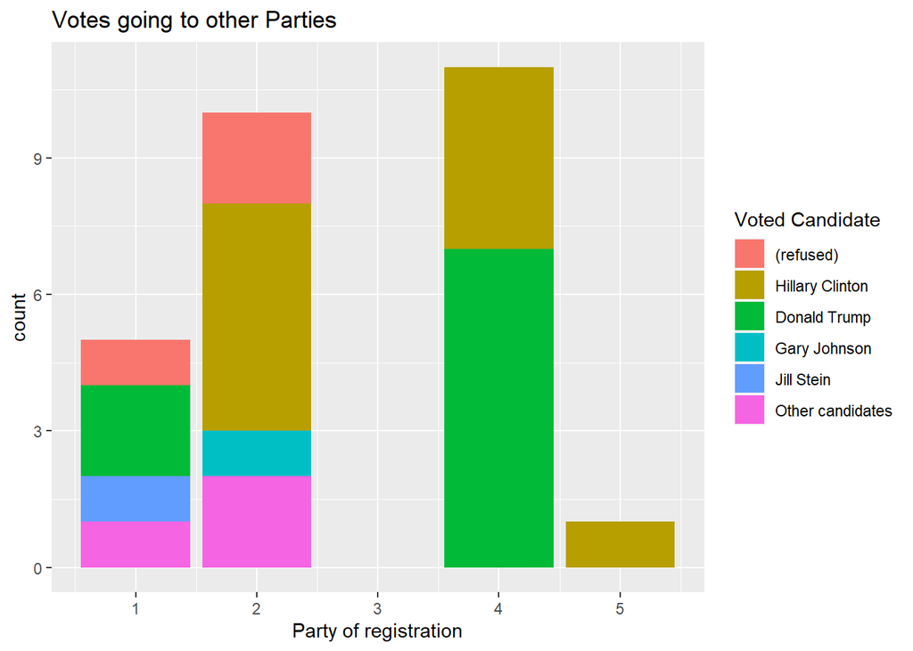

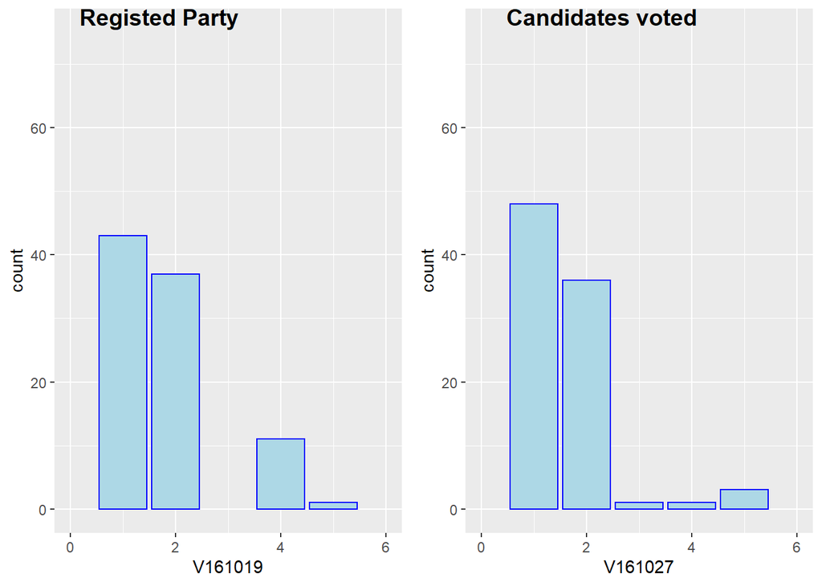

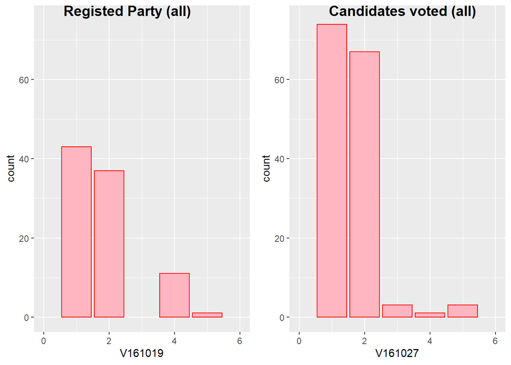

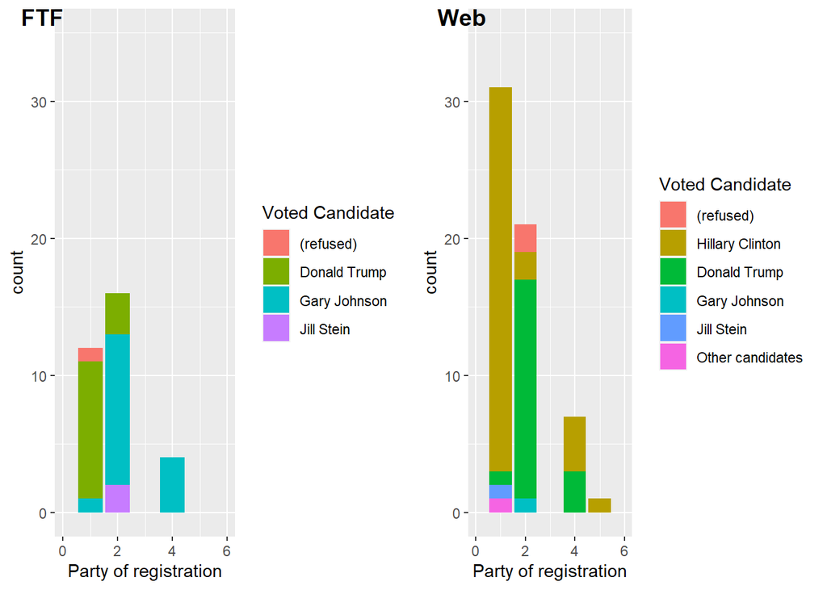

From the graphs above, we can clearly see that respondent interviewed face-to-face are far less favoring Hillary, albeit the small sample size. Let’s also look at social media’s data for further investigation.

#### data from tweeter

Based on my data found from tweeter:

| Name | Counts |
| --- | --- |
| Trump | 26142747 |
| Hillary | 13532345 |
| Bernie | 5804720 |
| the POTUS account | 15916812 |

Trump has the most followers, followed by the POTUS account, then Hillary, and then Bernie.

Then I analysed which hashtag had appeared more:“MakeAmericaGreatAgain”, “DumpTrump”, “imwithher”, or “lockherup”.

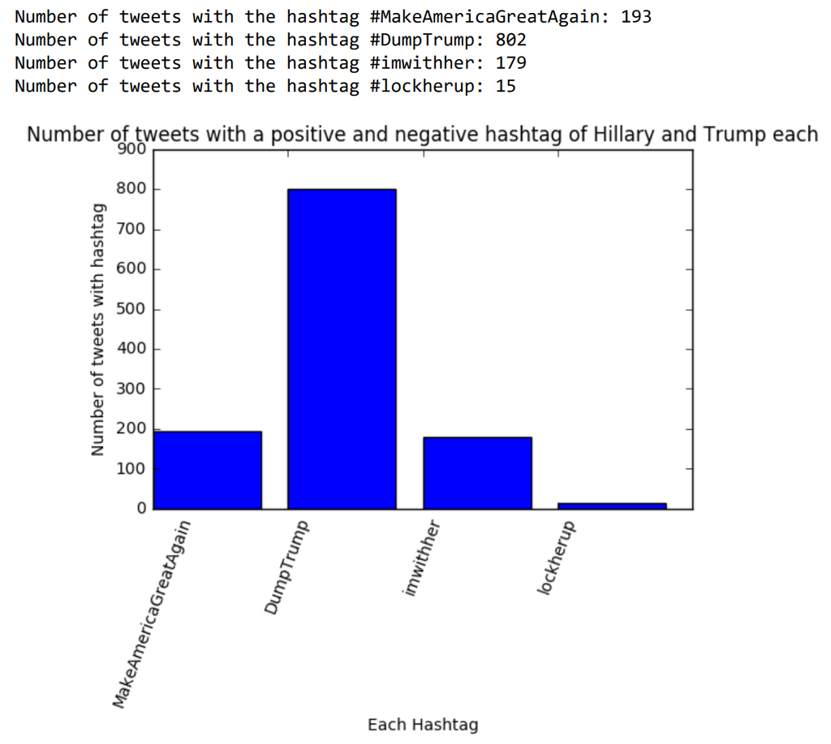

hashtags of Trump and Hillary

### Conclusion

By looking at both ANES and tweeter datasets, we have a clearer idea of how voters favor the 2016 candidates. Perhaps the US citizen’s voting preference didn’t change over election cycle. Instead, it might be the method of our sampling that led to this false impression. If we only look at voters who use web and social medias, there’s an apparent favor over Hillary. However, if we take into account those who prefer offline voting, then this group of population might be contributing the winning of Trump’s 2016 Presidential election.